# Machine Learning Toolbox

# Part 1: Regressions Models: Fitting & Evaluating Performance

Supervised Learning  
* caret R package * predictive modeling * target variable (the variable you want to predict)

two types of models classification - qualitative regression - quantitative

Use metrics to evaulate models RMSE out-of-sample erroris a better approach to prevent being too optimistic about your model due to the fact that we use RMSE to evaluate the model (training data) in the first place

```r
library(tidyverse)
names(diamonds)
```

```
 [1] "carat"   "cut"     "color"   "clarity" "depth"   "table"   "price"   "x"       "y"       "z"
```

```r
#create model of on the diamonds data set predciting price using all other variables as predictors (price ~ .)
model <- lm(data = diamonds, formula = price ~ .)
#make predictions on original dataset using the model we just built
p <- predict(object = model, newdata = diamonds)
#compute errors:
error <- p - diamonds$price
#Calculate RMSE:
sqrt(mean(error^2))
```

```
[1] 1129.843
```

## Out-of-sample error

Out-of-sample error  
* We Want models that don’t overfit, and generalize well * Do the models perform well on new data * Test set

```r
#order the dataset randomly to remove any biases in the ordering of the data
#use set.seed to reproduce the same random split each time you run the script
set.seed(42)
#use sample to shuffle the data
rows <- sample(nrow(diamonds))
# Randomly order data
diamonds <- diamonds[rows, ]
```

Next, let’s split the data 80/20, the 80% being the training set and the last 20% being the test set.

```r
# Determine row to split on: split
split <- round(nrow(diamonds) * .80)
# Create training dataset
train <- diamonds[1:split, ]
# Create test dataset
test <- diamonds[(split + 1): nrow(diamonds), ]
```

Now we can apply the concepts of the linear model to the training and test sets

```r
# Fit lm model on train: model
model <- lm(price ~ ., train)
# Predict on test: p
p <- predict(model, test)
# Compute errors: error
error <- p - test$price
# Calculate RMSE
sqrt(mean(error^2))
```

```
[1] 1136.596
```

## Cross-Validation

Cross-Validation * 11x is time expensive as fitting a single model. * bootstrap modeling is another approach similar to CV

The benefit of CV is that it gives you multiple out-of-sample error estimates to critique the model. If the estimates are similar, you can be more certain of the model’s accuracy. ANd vice versa, if the estimates give different outputs, the model does not generalize well and there may be a problem with it.

notes on train function  
* pass the method for modeling to the main train() function * pass the method for cross-validation to the trainControl() function.

```r
library(caret) # for modeling
library(mlbench) #for machine learning datasets
#cross-validation method of the diamonds dataset using the train() function
model <- train(
  price ~ ., diamonds,
  method = "lm",
  trControl = trainControl(
    method = "cv", number = 10,
    verboseIter = TRUE
  )
)
# Print model to console
print(model)
```

```
Linear Regression

53940 samples
    9 predictor

No pre-processing
Resampling: Cross-Validated (10 fold)
Summary of sample sizes: 48547, 48546, 48547, 48546, 48546, 48545, ...
Resampling results:

  RMSE     Rsquared
  1131.04  0.9196676

Tuning parameter 'intercept' was held constant at a value of TRUE
```

```r
#another example using the Boston housing dataset
data("BostonHousing")
Boston.model <- train(
  medv ~ ., BostonHousing,
  method = "lm",
  trControl = trainControl(
    method = "cv", number = 5,
    verboseIter = TRUE
  )
)
# Print model to console
print(Boston.model)
```

```
Linear Regression

506 samples
 13 predictor

No pre-processing
Resampling: Cross-Validated (5 fold)
Summary of sample sizes: 404, 404, 406, 405, 405
Resampling results:

  RMSE      Rsquared
  4.807921  0.7261456

Tuning parameter 'intercept' was held constant at a value of TRUE
```

```r
#repeated cross-fold validation to improve the estimate of the test-set error
#using argument "repeats ="
Boston.model.repeated <- train(
  medv ~ ., BostonHousing,
  method = "lm",
  trControl = trainControl(
    method = "cv", number = 5,
    repeats = 5, verboseIter = TRUE
  )
)
# Print model to console
print(Boston.model.repeated)
```

```
Linear Regression

506 samples
 13 predictor

No pre-processing
Resampling: Cross-Validated (5 fold)
Summary of sample sizes: 404, 404, 406, 404, 406
Resampling results:

  RMSE      Rsquared
  4.912663  0.7163207

Tuning parameter 'intercept' was held constant at a value of TRUE
```

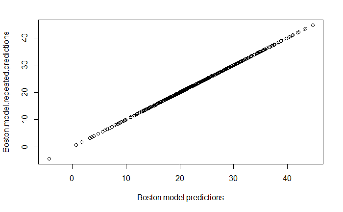

```r
#you can use the predict function on the model created with the train() function to make predictions about the original dataset
Boston.model.predictions <- predict(Boston.model, BostonHousing)
Boston.model.repeated.predictions <- predict(Boston.model.repeated, BostonHousing)
plot(x = Boston.model.predictions, y = Boston.model.repeated.predictions)
```

# Part 2) Logistic Regression

Classification Models are used to determine a categorical (qualitative) target variable.

Rules for training and testing are the same as regression (quantitative) models.

We will use the SONAR datatset which is part of the mlbench package.

```r
#load the Sonar dataset to the enviornment
data("Sonar")
# Shuffle row indices: rows
rows <- sample(nrow(Sonar))
# Randomly order data: Sonar
Sonar <- Sonar[rows,]
# Identify row to split on: split
split <- round(nrow(Sonar) * .6)
# Create train (60%)
train <- Sonar[1:split, ]
# Create test (40%)
test <- Sonar[(split + 1): nrow(Sonar), ]
```

The `glm` function is a logistic regression model function which allows for more variet types of regression model.

*glm* is an abbreviation for generalized linear model

We will use the argument `family = "binomial"` to specify we want logistic regression.

```r
# Fit glm model: model
model <- glm(Class ~ ., train, family = "binomial")
```

```
glm.fit: algorithm did not convergeglm.fit: fitted probabilities numerically 0 or 1 occurred
```

```r
model
```

```
Call:  glm(formula = Class ~ ., family = "binomial", data = train)

Coefficients:
(Intercept)           V1           V2           V3           V4           V5           V6           V7           V8           V9          V10          V11
      65.38        23.75      -578.03       554.28      -287.29       -50.23       -48.16       387.81       -73.23      -115.68       206.94      -276.97
        V12          V13          V14          V15          V16          V17          V18          V19          V20          V21          V22          V23
     -36.95        15.08      -146.82        96.24       -29.58       143.59      -167.34        40.29       -44.23       175.29      -159.87        92.27
        V24          V25          V26          V27          V28          V29          V30          V31          V32          V33          V34          V35
    -220.30       328.42      -337.50       197.88      -120.22        89.26      -162.72       272.39      -119.28       -31.85        90.48      -177.41
        V36          V37          V38          V39          V40          V41          V42          V43          V44          V45          V46          V47
     260.65        15.83      -178.61       108.81       -45.04        15.91       -51.28        50.68       -18.78       -71.38       127.23      -465.00
        V48          V49          V50          V51          V52          V53          V54          V55          V56          V57          V58          V59
     451.08      -794.45      1102.03       415.51      -526.82       435.09     -1548.68      1715.39       776.93       139.26      -402.71      -867.93
        V60
    1067.66

Degrees of Freedom: 124 Total (i.e. Null);  64 Residual
Null Deviance:      171.9
Residual Deviance: 3.212e-09    AIC: 122
```

```r
# Predict on test: p
p <- predict(model, test, type = "response")
p
```

```
         140          193          162          149          106          121           38          168          122           51          124           89
2.220446e-16 2.220446e-16 2.220446e-16 2.220446e-16 1.272104e-10 2.220446e-16 1.000000e+00 8.588897e-10 2.220446e-16 1.000000e+00 3.654727e-06 5.442427e-07
          42           18           93          136            9           78          158           31           27           67          191           34
1.000000e+00 2.220446e-16 1.000000e+00 2.220446e-16 2.220446e-16 1.000000e+00 9.994550e-01 1.000000e+00 6.203126e-04 1.000000e+00 1.060863e-01 1.000000e+00
         157          172           44            4           85          194          160          115          180          164          127           98
4.838289e-01 2.220446e-16 1.000000e+00 2.220446e-16 6.868458e-08 1.000000e+00 1.000000e+00 2.220446e-16 1.000000e+00 9.999988e-01 2.220446e-16 1.000000e+00
          28          175          110           82           81            6           83           74          202           32           24           25
1.828679e-03 2.220446e-16 1.000000e+00 2.220446e-16 1.000000e+00 2.220446e-16 2.220446e-16 2.220446e-16 2.220446e-16 1.000000e+00 1.000000e+00 1.000000e+00
         132           69           13          117           91          188           94           12           88           46          109           75
1.000000e+00 9.999949e-01 1.000000e+00 2.220446e-16 1.000000e+00 2.220446e-16 5.649836e-01 7.796510e-01 1.000000e+00 9.999975e-01 2.220446e-16 2.194982e-02
         104           55          105          177           68          184          151          108          170           54          206           19
4.326981e-07 1.000000e+00 2.220446e-16 2.220446e-16 1.000000e+00 2.220446e-16 1.000000e+00 9.207908e-01 2.220446e-16 1.000000e+00 1.438829e-08 1.000000e+00
         186           76          156          179           70          143          116           20           10          159           84
2.220446e-16 1.000000e+00 1.000000e+00 9.999847e-01 1.000000e+00 2.220446e-16 1.000000e+00 2.220446e-16 1.000000e+00 2.220446e-16 2.220446e-16
```

## The Confusion Matrix

Confusion Matrix reveals how confused the model is.

```
             Reference
       Yes               No
Yes  True Positive   False Positive
No   False Negative  True Negative
```

Prediction (on the Y axis)

The Sensitivity tell you the True Positive Rate The Specificity tell you the true negative rate

```r
# Calculate class probabilities: p_class
p_class <- ifelse(p > .5, "M", "R")
p_class
```

```
140 193 162 149 106 121  38 168 122  51 124  89  42  18  93 136   9  78 158  31  27  67 191  34 157 172  44   4  85 194 160 115 180 164 127  98  28 175 110
"R" "R" "R" "R" "R" "R" "M" "R" "R" "M" "R" "R" "M" "R" "M" "R" "R" "M" "M" "M" "R" "M" "R" "M" "R" "R" "M" "R" "R" "M" "M" "R" "M" "M" "R" "M" "R" "R" "M"
 82  81   6  83  74 202  32  24  25 132  69  13 117  91 188  94  12  88  46 109  75 104  55 105 177  68 184 151 108 170  54 206  19 186  76 156 179  70 143
"R" "M" "R" "R" "R" "R" "M" "M" "M" "M" "M" "M" "R" "M" "R" "M" "M" "M" "M" "R" "R" "R" "M" "R" "R" "M" "R" "M" "M" "R" "M" "R" "M" "R" "M" "M" "M" "M" "R"
116  20  10 159  84
"M" "R" "M" "R" "R"
```

```r
# Create confusion matrix
confusionMatrix(p_class, test$Class)
```

```
Confusion Matrix and Statistics

          Reference
Prediction  M  R
         M 13 27
         R 29 14

               Accuracy : 0.3253
                 95% CI : (0.2265, 0.437)
    No Information Rate : 0.506
    P-Value [Acc > NIR] : 0.9997

                  Kappa : -0.3488
 Mcnemar's Test P-Value : 0.8937

            Sensitivity : 0.3095
            Specificity : 0.3415
         Pos Pred Value : 0.3250
         Neg Pred Value : 0.3256
             Prevalence : 0.5060
         Detection Rate : 0.1566
   Detection Prevalence : 0.4819
      Balanced Accuracy : 0.3255

       'Positive' Class : M
```

## Class Probabilities & Class Predictions

```r
# Apply threshold of 0.9: p_class
p_class <- ifelse(p > .9, "M", "R")
# Create confusion matrix
confusionMatrix(p_class, test$Class)
```

```
Confusion Matrix and Statistics

          Reference
Prediction  M  R
         M 13 25
         R 29 16

               Accuracy : 0.3494
                 95% CI : (0.248, 0.4619)
    No Information Rate : 0.506
    P-Value [Acc > NIR] : 0.9986

                  Kappa : -0.2999
 Mcnemar's Test P-Value : 0.6831

            Sensitivity : 0.3095
            Specificity : 0.3902
         Pos Pred Value : 0.3421
         Neg Pred Value : 0.3556
             Prevalence : 0.5060
         Detection Rate : 0.1566
   Detection Prevalence : 0.4578
      Balanced Accuracy : 0.3499

       'Positive' Class : M
```

In contrast we can make the cutoff 10% to increase the amount of mines that are predicted with lower certainty.

```r
p_class <- ifelse(p> .1, "M", "R")
confusionMatrix(p_class, test$Class)
```

```
Confusion Matrix and Statistics

          Reference
Prediction  M  R
         M 15 27
         R 27 14

               Accuracy : 0.3494
                 95% CI : (0.248, 0.4619)
    No Information Rate : 0.506
    P-Value [Acc > NIR] : 0.9986

                  Kappa : -0.3014
 Mcnemar's Test P-Value : 1.0000

            Sensitivity : 0.3571
            Specificity : 0.3415
         Pos Pred Value : 0.3571
         Neg Pred Value : 0.3415
             Prevalence : 0.5060
         Detection Rate : 0.1807
   Detection Prevalence : 0.5060
      Balanced Accuracy : 0.3493

       'Positive' Class : M
```

## The ROC curve

ROC Curve - Receiver Operating Characteristic Curve Developed during WW2 to identify bombers

Purpose of the ROC curve is to evaluate all possible thresholds for splitting predicted probabilities into predicted classes.

**The `caTools` package is useful for computing ROC curves**

Primarily the `colAUC()` function

```
             [,1]
M vs. R 0.7375145
```

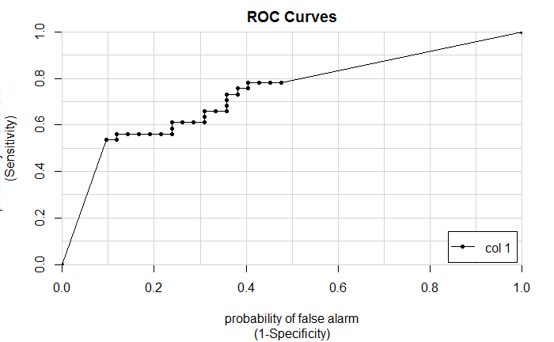

```r
library(caTools)
# Predict on test: p
p <- predict(model, test, type = "response")
# Make ROC curve
colAUC(p, test$Class, plotROC = TRUE)
```

Area Under the Curve: AUC

Ranges from 0 to 1 where:

- 0.5 = random guessing
- 1 = model always right
- 0 = model always wrong

Can think about AUC as a letter grade: .9 = A, .8 = B, …etc…

```r
# traincontrol is part of the caret package
myControl <- trainControl(
  method = "cv",
  number = 10,
  summaryFunction = twoClassSummary,
  classProbs = TRUE, # IMPORTANT!
  verboseIter = TRUE
)
# using the mycontrol object above, we can fit a model that uses AUC rather than accuracy to fit/evaluate the model
# Train glm with custom trainControl: model
model <- train(form = Class ~ ., data =  Sonar, method = "glm", trControl = myControl)
```

```
The metric "Accuracy" was not in the result set. ROC will be used instead.
```

```
glm.fit: algorithm did not convergeglm.fit: fitted probabilities numerically 0 or 1 occurred
```

[output not shown]

[output not shown]

[output not shown]

[output not shown]

[output not shown]

[output not shown]

[output not shown]

[output not shown]

[output not shown]

[output not shown]

```r
# Print model to console
print(model)
```

```
Generalized Linear Model

208 samples
 60 predictor
  2 classes: 'M', 'R'

No pre-processing
Resampling: Cross-Validated (10 fold)
Summary of sample sizes: 187, 187, 188, 186, 187, 188, ...
Resampling results:

  ROC        Sens       Spec
  0.7306944  0.7386364  0.6677778
```

# Part 3) Tuning Model Parameters to Improve Performance

Random Forests * very flexible * good for beginners * robust overfitting * yields are very accurate, non-linear models

hyperparameters must be estimated and can impact the model fit.

Follows the decision tree pattern * improves the accuracy by fitting many trees * fits each to a bootstrap sample of the data * bootstrap aggregation, or bagging * randomly sample columns at each split

In the following example we will use the ‘ranger’ function part of the `ranger` package. This is a rewrite of the classic `randomForest` package and fits models much faster giving the same results.

```r
library(ranger)
#download the wine quality datasets
whites <- read.csv("https://archive.ics.uci.edu/ml/machine-learning-databases/wine-quality/winequality-white.csv", header = TRUE, sep = ";")
reds <- read.csv("https://archive.ics.uci.edu/ml/machine-learning-databases/wine-quality/winequality-red.csv", header = TRUE, sep = ";")
whites$color <- factor("white")
reds$color <- factor("red")
wine <-  rbind(whites, reds)
# Fit random forest: model
wine_model <- train(
  quality ~ .,
  tuneLength = 1,
  data = wine, method = "ranger",
  trControl = trainControl(method = "cv", number = 5, verboseIter = TRUE)
)
# Print model to console
wine_model
```

```
Random Forest

6497 samples
  12 predictor

No pre-processing
Resampling: Cross-Validated (5 fold)
Summary of sample sizes: 5199, 5198, 5197, 5197, 5197
Resampling results:

  RMSE       Rsquared
  0.6023731  0.532504

Tuning parameter 'mtry' was held constant at a value of 3
```

## tuning

Random forests require tuning

hyperparamters control how the model is fit: these must be selected “by hand” before the model is fit

Most important hyperparameter is ‘mtry’

- Number of randomly selected variables used at each split
- lower value = more random
- higher value = less random

It is difficult to know the best value in advance

the `tunelength` argument will specify how many variations to try ANother way to think of this is that the higher the tunelength, the more models will be fit allowing you to potentially find a better model.

```r
# Fit random forest: model
wine_model2 <- train(
  quality ~ .,
  tuneLength = 3,
  data = wine, method = "ranger",
  trControl = trainControl(method = "cv", number = 5, verboseIter = TRUE)
)
# Print model to console
wine_model2
```

```
Random Forest

6497 samples
  12 predictor

No pre-processing
Resampling: Cross-Validated (5 fold)
Summary of sample sizes: 5197, 5198, 5197, 5198, 5198
Resampling results across tuning parameters:

  mtry  RMSE       Rsquared
   2    0.6040563  0.5329082
   7    0.6024342  0.5285578
  12    0.6061548  0.5208822

RMSE was used to select the optimal model using  the smallest value.
The final value used for the model was mtry = 7.
```

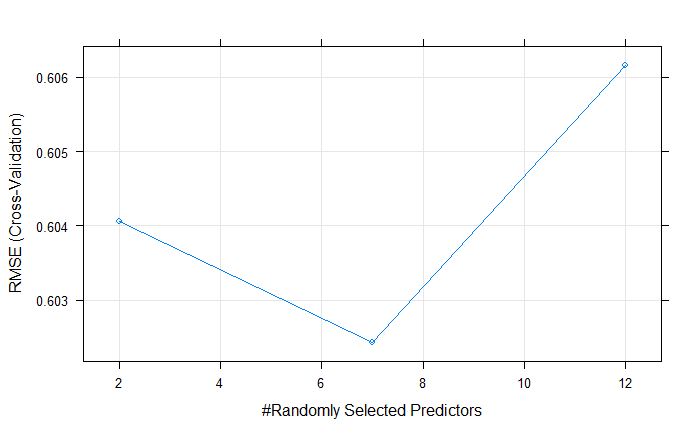

```r
# Plot model
plot(wine_model2)
```

## custom tuning grids

```r
# create custom tuning grid
mygrid <- data.frame(mtry = c(2, 3, 7, 11, 12))
# Fit random forest: model
wine_model3 <- train(
  quality ~ .,
  tuneGrid = mygrid,
  data = wine, method = "ranger",
  trControl = trainControl(method = "cv", number = 5, verboseIter = TRUE)
)
# Print model to console
wine_model3
```

```
Random Forest

6497 samples
  12 predictor

No pre-processing
Resampling: Cross-Validated (5 fold)
Summary of sample sizes: 5198, 5198, 5197, 5197, 5198
Resampling results across tuning parameters:

  mtry  RMSE       Rsquared
   2    0.6067943  0.5284645
   3    0.6053266  0.5276057
   7    0.6068279  0.5215501
  11    0.6082798  0.5180257
  12    0.6092858  0.5160235

RMSE was used to select the optimal model using  the smallest value.
The final value used for the model was mtry = 3.
```

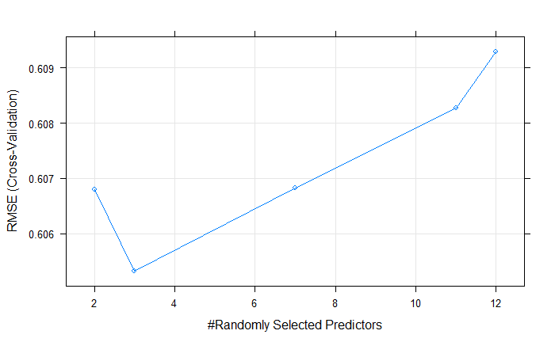

```r
# Plot model
plot(wine_model3)
```

## glmnet

- an extension of glm models wit built-in variable selection
- Helps deal with collinearity and smaller sample sizes
- Two primary forms:
  - Lasso regression (penalizes # of non-zero coeffs)
  - Ridge regression (penalizes absolute magnitude of coeffs)
- Attempts to fins a parsimonious model (simple)
- Pairs well with random forest models

many paremeters to tune: alpha [0,1]: pure lasso to pure ridge lambda (0, infinite): size of the penalty

```r
library(glmnet)
# Create custom trainControl: myControl
myControl <- trainControl(
  method = "cv", number = 10,
  summaryFunction = twoClassSummary,
  classProbs = TRUE, # IMPORTANT!
  verboseIter = TRUE
)
glmnet_model <- train(
  Class ~ ., #formula
  Sonar, #data
  method = 'glmnet', #type of model
  trControl = myControl)
```

```
The metric "Accuracy" was not in the result set. ROC will be used instead.
```

```r
# Print model to console
glmnet_model
```

```
glmnet

208 samples
 60 predictor
  2 classes: 'M', 'R'

No pre-processing
Resampling: Cross-Validated (10 fold)
Summary of sample sizes: 187, 188, 186, 187, 188, 187, ...
Resampling results across tuning parameters:

  alpha  lambda        ROC        Sens       Spec
  0.10   0.0004318733  0.8506818  0.7659091  0.6900000
  0.10   0.0043187332  0.8490152  0.7840909  0.7511111
  0.10   0.0431873324  0.8537626  0.7840909  0.7522222
  0.55   0.0004318733  0.8450000  0.7659091  0.7000000
  0.55   0.0043187332  0.8458838  0.7840909  0.7311111
  0.55   0.0431873324  0.8318687  0.7477273  0.7322222
  1.00   0.0004318733  0.8397475  0.7659091  0.6866667
  1.00   0.0043187332  0.8483081  0.7931818  0.7311111
  1.00   0.0431873324  0.8354545  0.7840909  0.7000000

ROC was used to select the optimal model using  the largest value.
The final values used for the model were alpha = 0.1 and lambda = 0.04318733.
```

```r
# Print maximum ROC statistic
max(glmnet_model[["results"]])
```

```
[1] 1
```

## glmnet with custom tuning grid

2 tuning parameters: alpha and lambda

for 1 alpha, all values of lambda fit simultaneously

many models for the “price” of one

```r
glmnet_model2 <- train(
  Class ~ .,
  Sonar,
  tuneGrid = expand.grid(alpha = 0:1,
                         lambda = seq(0.0001, 1, length = 20)),
  method = "glmnet",
  trControl = myControl
)
```

```
The metric "Accuracy" was not in the result set. ROC will be used instead.
```

```r
# Print model to console
glmnet_model2
```

```
glmnet

208 samples
 60 predictor
  2 classes: 'M', 'R'

No pre-processing
Resampling: Cross-Validated (10 fold)
Summary of sample sizes: 187, 188, 187, 187, 187, 188, ...
Resampling results across tuning parameters:

  alpha  lambda      ROC        Sens       Spec
  0      0.00010000  0.8607912  0.7568182  0.7444444
  0      0.05272632  0.8672896  0.7750000  0.7755556
  0      0.10535263  0.8704209  0.7931818  0.7855556
```

[output cut: 40 more lines]

```r
# Print maximum ROC statistic
max(glmnet_model2[["results"]][["ROC"]])
```

```
[1] 0.8704209
```

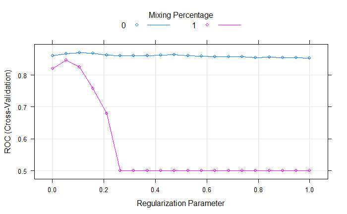

```r
plot(glmnet_model2)
```

# Pre-processing Data

## median imputation

Replace missing values with median values to run your model.

```r
#retrieve breast cancer (WI) dataset from the UCI machine learning repository

data("BreastCancer")

#split daya into 'formula' and response sets
breast_cancer_x <- BreastCancer[2:10] #predictors, a.k.a. formula variables
breast_cancer_x <-  map_df(.x = breast_cancer_x, .f = as.integer)

breast_cancery_y <- BreastCancer$Class # the response variable

breastcancer_model <- train(x = breast_cancer_x, #another way to  specify the model formula
                            y = breast_cancery_y, #y = the response variable
                            method = "glm",
                            trControl = myControl,
                            preProcess = "medianImpute")
breastcancer_model
```

[output not shown]

## KNN Imputation

While median imputation is a fast and useful method for dealing with missing values, it can prdoduce incorrect results if there is systematic bias in the dataset.

K nearest neighbors imputation imputes based on “similar” non-missing rows.